# Hearthstone Decks (on Hearthpwn)

### 4.7 Advanced questions

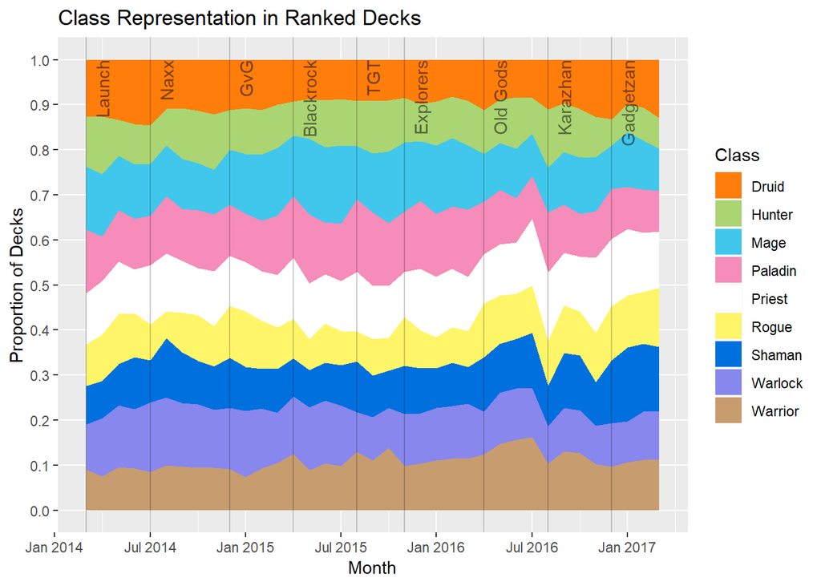

> What explains the shift in deck representation for August 2016 (launch of One Night in Karazhan)?

```r
deck_attr %>%
    filter(deck_type == "Ranked Deck",
           deck_format == "S") %>%
    group_by(deck_class, hsmonth) %>%
    summarise(n_decks = n()) %>%
    mutate(n_prev = lag(n_decks, order_by = hsmonth),
           delta = n_decks - n_prev) %>%
    filter(hsmonth == "2016-08") %>%
    arrange(desc(delta))
```

```
## # A tibble: 9 x 5
## # Groups:   deck_class [9]
##   deck_class hsmonth       n_decks n_prev delta
##   <fct>      <S3: yearmon>   <int>  <int> <int>
## 1 Hunter     Aug 2016          975    287   688
## 2 Paladin    Aug 2016          985    341   644
## 3 Priest     Aug 2016         1126    531   595
## 4 Druid      Aug 2016          817    303   514
## 5 Mage       Aug 2016          734    331   403
## 6 Rogue      Aug 2016          747    376   371
## 7 Shaman     Aug 2016          667    438   229
## 8 Warlock    Aug 2016          612    387   225
## 9 Warrior    Aug 2016          772    580   192
```

Hunter, Paladin and Priest had largest increase in submissions.

```r
pop_bymonth %>%
    filter(deck_class %in% c("Hunter", "Paladin", "Priest"),
           hsmonth == "2016-08",
           card_set == "One Night in Karazhan") %>%
    group_by(deck_class) %>%
    top_n(5, n_decks) %>%
    select(deck_class, name, cardClass, rarity, n_decks) %>%
    arrange(deck_class, desc(n_decks))
```

```
## # A tibble: 15 x 5
## # Groups:   deck_class [3]
##    deck_class name                cardClass rarity    n_decks
##    <fct>      <chr>               <fct>     <fct>       <int>
##  1 Hunter     Cloaked Huntress    Hunter    Common        502
##  2 Hunter     Kindly Grandmother  Hunter    Common        373
##  3 Hunter     Barnes              Neutral   Legendary     331
##  4 Hunter     Cat Trick           Hunter    Rare          189
##  5 Hunter     The Curator         Neutral   Legendary      76
##  6 Paladin    Ivory Knight        Paladin   Rare          395
##  7 Paladin    Nightbane Templar   Paladin   Common        295
##  8 Paladin    The Curator         Neutral   Legendary     258
##  9 Paladin    Barnes              Neutral   Legendary     150
## 10 Paladin    Moroes              Neutral   Legendary     127
## 11 Priest     Priest of the Feast Priest    Common        476
## 12 Priest     Onyx Bishop         Priest    Rare          435
## 13 Priest     Barnes              Neutral   Legendary     378
## 14 Priest     Purify              Priest    Common        117
## 15 Priest     Arcane Giant        Neutral   Epic          100
```

## 5 Unpopular Cards

> Are there any cards that are not used in Ranked decks?

```r
simple_cards %>%
    # filter out the Un'Goro expansion, and Hero cards
    filter(card_set != "Journey to Un\'Goro",
           type != "Hero") %>%
    filter(!(dbfId %in% unique(ranked_qtys$card_id))) %>%
    select(dbfId, name, cardClass, type, card_set)
```

```
## [1] dbfId     name      cardClass type      card_set
## <0 rows> (or 0-length row.names)
```

Apparently not. Then what were the least popular (Neutral) cards?

```r
pop_cards_all %>%
    filter(cardClass == "Neutral") %>%
    arrange(n_decks) %>%
    select(card_id, name, n_decks, rarity, type, card_set)
```

```
## # A tibble: 432 x 6
##    card_id name                n_decks rarity type   card_set
##      <int> <chr>                 <int> <fct>  <fct>  <fct>
##  1   40611 Tanaris Hogchopper       12 Common Minion Mean Streets of Gadg~
##  2   40928 Streetwise Investi~      12 Common Minion Mean Streets of Gadg~
##  3   40337 Wind-up Burglebot        23 Epic   Minion Mean Streets of Gadg~
##  4   40950 Worgen Greaser           25 Common Minion Mean Streets of Gadg~
##  5    2585 Coliseum Manager         31 Rare   Minion The Grand Tournament
##  6   40951 Grook Fu Master          32 Common Minion Mean Streets of Gadg~
##  7   40931 Backroom Bouncer         34 Rare   Minion Mean Streets of Gadg~
##  8   40745 Defias Cleaner           42 Epic   Minion Mean Streets of Gadg~
##  9   38522 Eldritch Horror          43 Common Minion Whispers of the Old ~
## 10    2259 Light's Champion         44 Rare   Minion The Grand Tournament
## # ... with 422 more rows
```

However, such a question would be biased towards newer cards since there would not be as many decks that use them. (And the results above clearly show it) A better question to ask would be:

> From the Basic and Classic sets, which Neutral cards are least used in ranked decks?

```r
pop_cards_all %>%
    filter(cardClass == "Neutral",
           card_set %in% c("Basic", "Classic")) %>%
    arrange(n_decks) %>%
    select(card_id, name, n_decks, rarity, type)
```

```
## # A tibble: 150 x 5
##    card_id name                n_decks rarity type
##      <int> <chr>                 <int> <fct>  <fct>
##  1     567 Windfury Harpy          114 Common Minion
##  2     712 War Golem               137 Free   Minion
##  3     765 Thrallmar Farseer       144 Common Minion
##  4    1653 Magma Rager             167 Free   Minion
##  5     715 Mana Wraith             210 Rare   Minion
##  6      37 Pint-Sized Summoner     217 Rare   Minion
##  7     339 Ironforge Rifleman      218 Free   Minion
##  8     134 Ravenholdt Assassin     227 Rare   Minion
##  9     424 Priestess of Elune      253 Common Minion
## 10    1687 Core Hound              264 Free   Minion
## # ... with 140 more rows
```

[figure not shown]

[figure not shown]

[figure not shown]

[figure not shown]

[figure not shown]

## 6 Further Work and Questions

In order of timeframe (earliest first)

- More granular analysis of popular cards (combining two or more categories)
  - Class, card set, mana cost, card type
- Notebook version 2:
  - Pre-planned structure/flow, consistent naming, focus on questions
- Dashboard
- Popularity of cards by mechanics
  - e.g. Battlecries, Deathrattles, Taunts
- Parsing card texts